# Gaussian Transformation

### *NOTE:- when you work on Regression models, first thing you have to check is are the independent variables we send to machune learning are 'Normally Distributed.*

*Some of the machine learning models like linear and Logistic regression assume that the variables are normally distributed. Reason why is b'coz they perform well on Gaussian distribution data.*

*The are some benefits of Gaussian Distribution, if your data is normally distributed it performs very very well on Gaussian distribution.*

*As n such distributions the observations of X variable to predict y variable vary across a greater range of values. Thus, Gaussian distribution variables may boost the machine learning algorithms performance.*

*If a variable is not normally distributed, sometimes it is possible to find a mathemetical tranformation so that they tranformed variable is Gaussian.*

## But the main question Lies how can we perform variables so that they follow Gaussian Distribution

```
1. Logaritmic Tanformation
2. Reciprocal Tranformation
3. Square root Transformation
4. Exponential Tranformation
5. Boxcox Transformation
```

### Linear Regression Assumption

Linear Regression has the following assumtions over the predictor variable X:

*Linear relatiionship with the outcome Y -- Multivariate normality -- No or little multico-linearity -- Homoscedacity*

1. Linear relationship : Linear regression needs the relationship between independetn and dependent variables to be linear. This linearity assumption can best be tested with scatter plots. However as quite obvious the linearity assemption is not valid for polynomial regression.
2. Multivarite normality : Regression analysis requires all variables to be multivariate normal. This assumption can best be checked with a histogram or a 'Q-Q-plot'. Normality can be checked with a goodness of fit test.
3. Multicolinearity : Regression assumes that there is a little or no multicolinearity in the data. Multicolinearity occurs when the idependent variables are too highly co-related with each other. You can use a correlation matrix to check if the variable are correlated to each other. You can remove one of the columns which are correlated while keeping the other.
4. Homoscedasticity : Homoscedasticity describes a situation in which the error term is the same across all values of the independent variables. The scatter plot is a good way to check whether the data are homoscedastic (meaning the residuals are equal across the regression line). If homoscedsticity is present, a non-linear correction might fix the problem.

## Do variable Distribution affect any other machine learning models?

The remaining machine learning models, including Neural Networks, Support Vector Machines, Tree Based methods and PCA do not make any assumtpions over the distribution of the independent variables, Usually we get a better model performance from a Gaussian like distribution.

## Let's work on transforming features to gaussian distribution

```python
import numpy as np
import pandas as pd
import matplotlib.pyplot as plt
import seaborn as sns
%matplotlib inline
```

```python
titanic = pd.read_csv(r"E:\PYTHON\Sep 3rd Practice Complete ML\Full Null values filling\titanic_train.csv")
```

```python
titanic.head()
```

|  | PassengerId | Survived | Pclass | Name | Sex | Age | SibSp | Parch | Ticket | Fare | Cabin | Embarked |
| --- | --- | --- | --- | --- | --- | --- | --- | --- | --- | --- | --- | --- |
| 0 | 1 | 0 | 3 | Braund, Mr. Owen Harris | male | 22.0 | 1 | 0 | A/5 21171 | 7.2500 | NaN | S |
| 1 | 2 | 1 | 1 | Cumings, Mrs. John Bradley (Florence Briggs Th... | female | 38.0 | 1 | 0 | PC 17599 | 71.2833 | C85 | C |
| 2 | 3 | 1 | 3 | Heikkinen, Miss. Laina | female | 26.0 | 0 | 0 | STON/O2. 3101282 | 7.9250 | NaN | S |
| 3 | 4 | 1 | 1 | Futrelle, Mrs. Jacques Heath (Lily May Peel) | female | 35.0 | 1 | 0 | 113803 | 53.1000 | C123 | S |
| 4 | 5 | 0 | 3 | Allen, Mr. William Henry | male | 35.0 | 0 | 0 | 373450 | 8.0500 | NaN | S |

```python
# Lets only use few columns which needs to be converted to Gaussian distribution

df = pd.read_csv(r"E:\PYTHON\Sep 3rd Practice Complete ML\Full Null values filling\titanic_train.csv",
                 usecols= ['Age','Fare','Survived','Pclass'])
```

```python
df.head()
```

|  | Survived | Pclass | Age | Fare |
| --- | --- | --- | --- | --- |
| 0 | 0 | 3 | 22.0 | 7.2500 |
| 1 | 1 | 1 | 38.0 | 71.2833 |
| 2 | 1 | 3 | 26.0 | 7.9250 |
| 3 | 1 | 1 | 35.0 | 53.1000 |
| 4 | 0 | 3 | 35.0 | 8.0500 |

```python
# Lets first check if there are any null values

df.isnull().sum()
```

```
Survived      0
Pclass        0
Age         177
Fare          0
dtype: int64
```

```python
# Since age column has null values lets take the base value of Pclass and fill those null values

# here we are using categorical filling

df.groupby(['Pclass'])['Age'].mean()
```

```
Pclass
1    38.233441
2    29.877630
3    25.140620
Name: Age, dtype: float64
```

```python
# Since the mean Age for pclass 1 is 38.23, lets fill it using a for loop

def impute_age(cols):
    Age = cols[0]
    Pclass = cols[1]

    if pd.isnull(Age):
        if Pclass == 1:
            return 38.23
        elif Pclass == 2:
            return 29.88
        elif Pclass == 3:
            return 25.14
    else:
        return Age
```

```python
df['Age'] = df[['Age','Pclass']].apply(impute_age, axis=1)
```

```python
df.isnull().sum()
```

```
Survived    0
Pclass      0
Age         0
Fare        0
dtype: int64
```

# Q-Q-plot

```python
# to use the stats plot we have import stats library

from scipy import stats
```

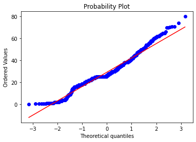

```python
stats.probplot(df['Age'], dist='norm', plot =plt)
plt.show()
```

```python
# Since most of the lines fall on the red line, we can consider that the Age is Gaussian distribution
```

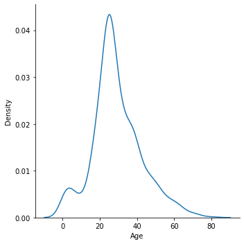

```python
sns.displot(df['Age'], kind = 'kde')
plt.show()
```

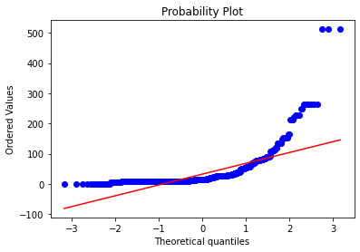

```python
# Now lets check for 'Fare' column

stats.probplot(df['Fare'], dist='norm', plot=plt)
plt.show()
```

```python
# Now we see the Fare column is not a Gaussian Distribution

# Let's convert it into Gaussian Distribution
```

```python
# Before we scale down, lets create a copy of the dataframe
```

```python
tit = df.copy()
```

```python
tit.head()
```

|  | Survived | Pclass | Age | Fare |
| --- | --- | --- | --- | --- |
| 0 | 0 | 3 | 22.0 | 7.2500 |
| 1 | 1 | 1 | 38.0 | 71.2833 |
| 2 | 1 | 3 | 26.0 | 7.9250 |
| 3 | 1 | 1 | 35.0 | 53.1000 |
| 4 | 0 | 3 | 35.0 | 8.0500 |

### 1. Standardization technique

```python
from sklearn.preprocessing import StandardScaler
```

```python
scaling = StandardScaler()
```

```python
scale = scaling.fit_transform(tit[['Fare']])
```

```python
scale
```

[output not shown]

[output cut: 836 more lines]

[output not shown]

```python
tit['Fare'] = pd.DataFrame(scale)
```

```python
tit.head()
```

|  | Survived | Pclass | Age | Fare |
| --- | --- | --- | --- | --- |
| 0 | 0 | 3 | 22.0 | -0.502445 |
| 1 | 1 | 1 | 38.0 | 0.786845 |
| 2 | 1 | 3 | 26.0 | -0.488854 |
| 3 | 1 | 1 | 35.0 | 0.420730 |
| 4 | 0 | 3 | 35.0 | -0.486337 |

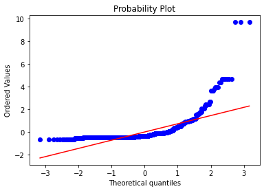

```python
# Now let's print and see if the fare column is Normally distributed

stats.probplot(tit['Fare'], dist='norm', plot=plt)
plt.show()
```

```python
tit['Log_Fare'] = np.log(tit['Fare'] +1)  # Why +1 means if there are values in Fare which has we can't find log of 0
                                          # Hence +1 is added
```

```python
tit.head()
```

|  | Survived | Pclass | Age | Fare | Log_Fare |
| --- | --- | --- | --- | --- | --- |
| 0 | 0 | 3 | 22.0 | -0.502445 | -0.698050 |
| 1 | 1 | 1 | 38.0 | 0.786845 | 0.580452 |
| 2 | 1 | 3 | 26.0 | -0.488854 | -0.671101 |
| 3 | 1 | 1 | 35.0 | 0.420730 | 0.351171 |
| 4 | 0 | 3 | 35.0 | -0.486337 | -0.666189 |

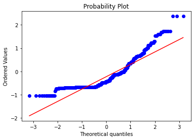

```python
# Now let's view the plot

stats.probplot(tit['Log_Fare'], dist='norm', plot=plt)
plt.show()
```

## 3. Reciprocal transformation

```python
tit['Rec_Fare'] = 1/(tit['Fare']+1)
```

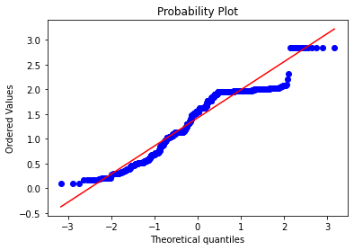

```python
# Now let's view the plot

stats.probplot(tit['Rec_Fare'], dist='norm', plot=plt)
plt.show()
```

# 4. Square root transformation

```python
tit['Sqr_Fare'] = tit['Fare']**(1/2)
```

[figure not shown]

```python
# Now let's view the plot

stats.probplot(tit['Sqr_Fare'], dist='norm', plot=plt)
plt.show()
```

# 5. Exponential Transformation

```python
tit['exp_Fare'] = tit['Fare']**(1/5)
```

[figure not shown]

```python
# Now let's view the plot

stats.probplot(tit['exp_Fare'], dist='norm', plot=plt)
plt.show()
```

# 6. Boxcox Transformation

```python
tit['box_Fare'], param = stats.boxcox(tit.Fare +1)

print('Optional lambda: ', param)
```

```
Optional lambda:  -1.126497530528394
```

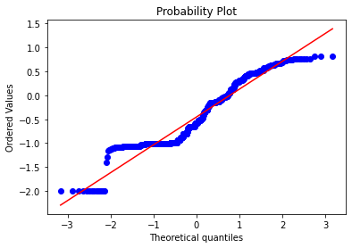

```python
# Now let's view the plot

stats.probplot(tit['box_Fare'], dist='norm', plot=plt)
plt.show()
```